# Asociacion de variables mediante análisis de regresión generalizado y análisis factorial multivariante

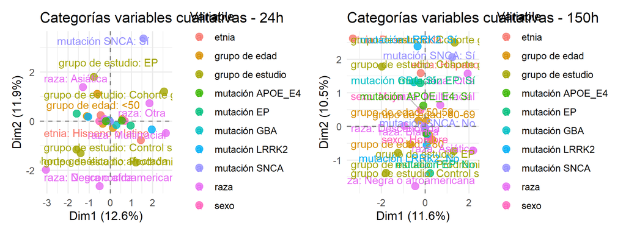

```r
# ============================================================
# GRÁFICO DE VARIABLES CUALITATIVAS
# Coloreado por variable con leyenda
# ============================================================

plot_quali_by_var(res.famd24,  titulo = "Categorías variables cualitativas - 24h") |
plot_quali_by_var(res.famd150, titulo = "Categorías variables cualitativas - 150h")
```

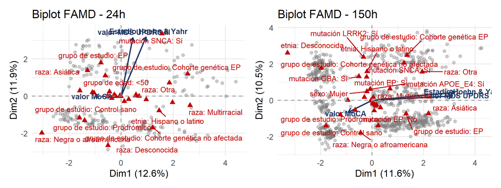

```r
#BIPLOT

biplot_24 <- ggplot() +
  geom_point(data = ind_coords_24,
             aes(x = Dim1, y = Dim2, color = SAA),
             alpha = 0.4, size = 1.5) +
  scale_color_manual(values = c("Negative" = "#FC4E07", "Positive" = "#00AFBB"),
                     name = "SAA status") +
  geom_segment(data = quanti_coords_24,
               aes(x = 0, y = 0, xend = Dim1, yend = Dim2),
               arrow = arrow(length = unit(0.2, "cm")),
               color = "#1F3864", linewidth = 0.7) +
  geom_text(data = quanti_coords_24,
            aes(x = Dim1 * 1.1, y = Dim2 * 1.1, label = variable),
            color = "#1F3864", size = 3, fontface = "bold") +
  geom_point(data = quali_coords_24,
             aes(x = Dim1, y = Dim2),
             shape = 17, size = 2, color = "#C00000") +
  geom_text_repel(data = quali_coords_24,
                  aes(x = Dim1, y = Dim2, label = categoria),
                  color = "#C00000", size = 3, max.overlaps = 15) +
  geom_hline(yintercept = 0, linetype = "dashed", color = "gray60") +
  geom_vline(xintercept = 0, linetype = "dashed", color = "gray60") +
  labs(title = "Biplot FAMD - 24h",
       x = paste0("Dim1 (", round(eig_24[1, 2], 1), "%)"),
       y = paste0("Dim2 (", round(eig_24[2, 2], 1), "%)")) +
  theme_minimal() +
  theme(legend.position = "right")

biplot_150 <- ggplot() +
  geom_point(data = ind_coords_150,
             aes(x = Dim1, y = Dim2, color = SAA),
             alpha = 0.4, size = 1.5) +
  scale_color_manual(values = c("Negative" = "#FC4E07", "Positive" = "#00AFBB"),
                     name = "SAA status") +
  geom_segment(data = quanti_coords_150,
               aes(x = 0, y = 0, xend = Dim1, yend = Dim2),
               arrow = arrow(length = unit(0.2, "cm")),
               color = "#1F3864", linewidth = 0.7) +
  geom_text(data = quanti_coords_150,
            aes(x = Dim1 * 1.1, y = Dim2 * 1.1, label = variable),
            color = "#1F3864", size = 3, fontface = "bold") +
  geom_point(data = quali_coords_150,
             aes(x = Dim1, y = Dim2),
             shape = 17, size = 2, color = "#C00000") +
  geom_text_repel(data = quali_coords_150,
                  aes(x = Dim1, y = Dim2, label = categoria),
                  color = "#C00000", size = 3, max.overlaps = 15) +
  geom_hline(yintercept = 0, linetype = "dashed", color = "gray60") +
  geom_vline(xintercept = 0, linetype = "dashed", color = "gray60") +
  labs(title = "Biplot FAMD - 150h",
       x = paste0("Dim1 (", round(eig_150[1, 2], 1), "%)"),
       y = paste0("Dim2 (", round(eig_150[2, 2], 1), "%)")) +
  theme_minimal() +
  theme(legend.position = "right")

biplot_24 | biplot_150
```

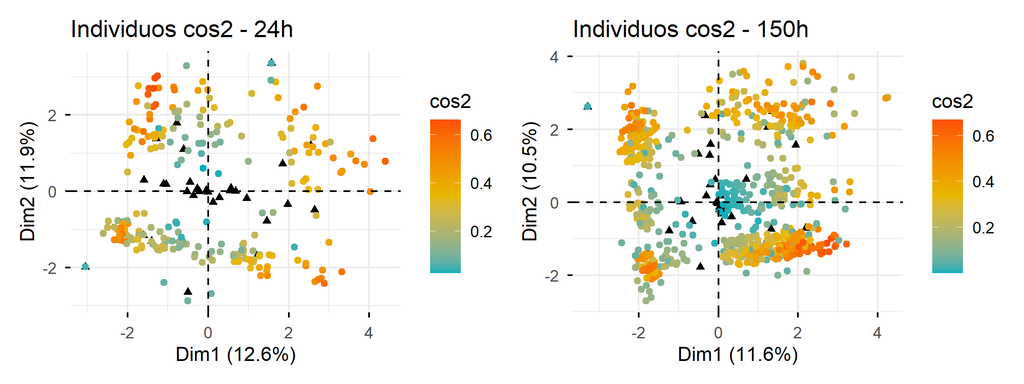

```r
# ============================================================
# GRÁFICO DE INDIVIDUOS
# ============================================================

ind24  <- get_famd_ind(res.famd24)
ind150 <- get_famd_ind(res.famd150)

fviz_famd_ind(res.famd24, labelsize = 6,
              col.ind = "cos2",
              gradient.cols = c("#00AFBB", "#E7B800", "#FC4E07"),
              geom = "point", repel = TRUE) + ggtitle("Individuos cos2 - 24h") |
fviz_famd_ind(res.famd150, labelsize = 6,
              col.ind = "cos2",
              gradient.cols = c("#00AFBB", "#E7B800", "#FC4E07"),
              geom = "point", repel = TRUE) + ggtitle("Individuos cos2 - 150h")
```

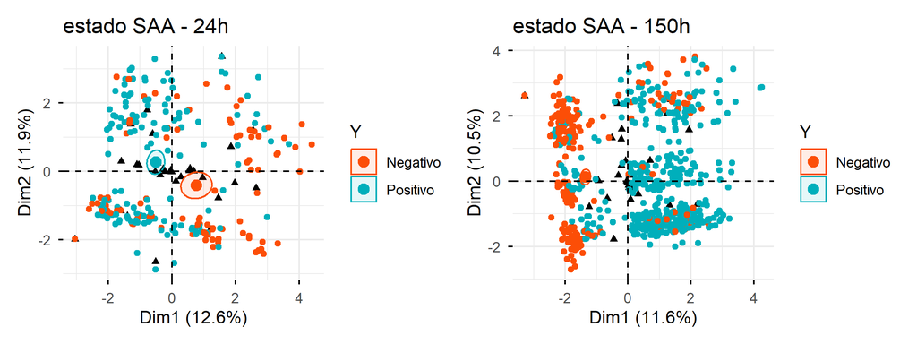

```r
fviz_famd_ind(res.famd24, labelsize = 6,
              habillage = "Y", palette = c("#FC4E07", "#00AFBB"),
              addEllipses = TRUE, ellipse.type = "confidence",
              geom = "point", repel = TRUE) + ggtitle("estado SAA - 24h") |
fviz_famd_ind(res.famd150, labelsize = 6,
              habillage = "Y", palette = c("#FC4E07", "#00AFBB"),
              addEllipses = TRUE, ellipse.type = "confidence",
              geom = "point", repel = TRUE) + ggtitle("estado SAA - 150h")
```

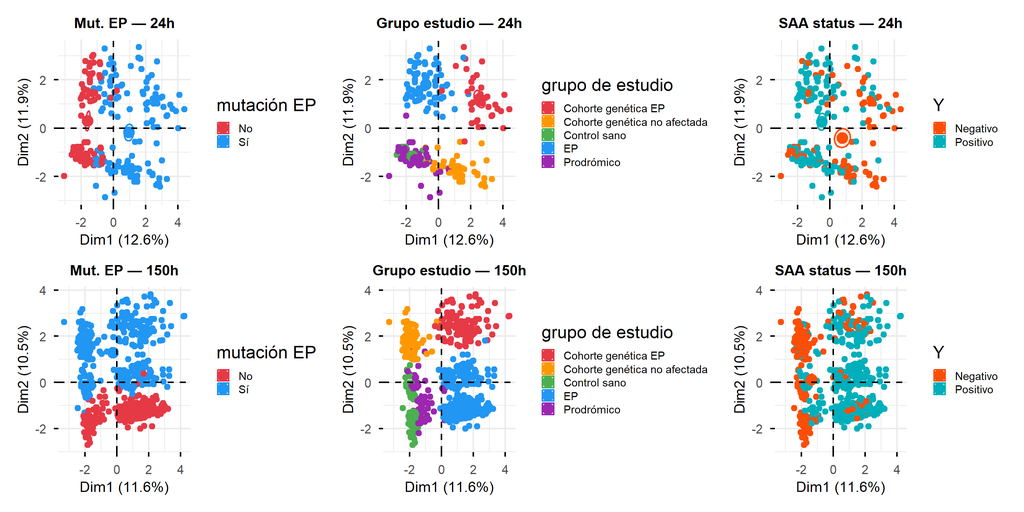

```r
(p1 | p2 | p3) /
(p1_150 | p2_150 | p3_150)
```

## MCA – Análisis de Correspondencias multiples

```r
ajustar_mca <- function(df, vars_nominales, y = "Y", ncp = 2) {

  df_mca <- df %>%
    dplyr::select(all_of(unique(c(vars_nominales, y)))) %>%
    mutate(across(everything(), as.factor))

  df_mca <- df_mca[, sapply(df_mca, function(x) dplyr::n_distinct(x, na.rm = TRUE) > 1), drop = FALSE]

  y_idx <- which(names(df_mca) == y)

  if (sum(is.na(df_mca[, setdiff(names(df_mca), y), drop = FALSE])) > 0) {
    imp <- missMDA::imputeMCA(df_mca[, setdiff(names(df_mca), y), drop = FALSE], ncp = ncp)
    df_mca_comp <- as.data.frame(imp$completeObs)
    df_mca_comp[[y]] <- df_mca[[y]]
    df_mca_comp[[y]] <- as.factor(df_mca_comp[[y]])
  } else {
    df_mca_comp <- df_mca
  }

  y_idx <- which(names(df_mca_comp) == y)
  res <- FactoMineR::MCA(df_mca_comp, quali.sup = y_idx, graph = FALSE)
  list(data = df_mca_comp, res = res)
}

plot_mca_biplot_y <- function(res_mca, df_mca, titulo = "") {

  # Coordenadas de individuos
  ind_coords <- as.data.frame(res_mca$ind$coord[, 1:2])
  colnames(ind_coords) <- c("Dim1", "Dim2")
  ind_coords$SAA <- df_mca$Y

  # Coordenadas de categorías de variables
  var_coords <- as.data.frame(res_mca$var$coord[, 1:2])
  colnames(var_coords) <- c("Dim1", "Dim2")
  var_coords$categoria <- rownames(var_coords)

  # Varianza explicada para los ejes
  eig <- get_eigenvalue(res_mca)

  ggplot() +
    # Individuos como puntos coloreados por SAA
    geom_point(data = ind_coords,
               aes(x = Dim1, y = Dim2, color = SAA),
               alpha = 0.4, size = 3) +
    scale_color_manual(values = c("Negativo" = "#FC4E07", "Positivo" = "#00AFBB"),
                       name = "Estado SAA") +
    # Categorías como triángulos con etiqueta
    geom_point(data = var_coords,
               aes(x = Dim1, y = Dim2),
               shape = 17, size = 3, color = "#C00000") +
    geom_text_repel(data = var_coords,
                    aes(x = Dim1, y = Dim2, label = categoria),
                    color = "#C00000", size = 6,
                    max.overlaps = 20,
                    fontface = "bold") +
    geom_hline(yintercept = 0, linetype = "dashed", color = "gray60") +
    geom_vline(xintercept = 0, linetype = "dashed", color = "gray60") +
    labs(
      title = titulo,
      x = paste0("Dim1 (", round(eig[1, 2], 1), "%)"),
      y = paste0("Dim2 (", round(eig[2, 2], 1), "%)")
    ) +
    theme_minimal(base_size = 11) +
    theme(
      axis.text    = element_text(size = 9),
      axis.title   = element_text(size = 11),
      plot.title   = element_text(size = 13, face = "bold", hjust = 0.5),
      legend.title = element_text(size = 10),
      legend.text  = element_text(size = 9)
    )
}
```

```r
# ── Ajuste del MCA con Y como variable suplementaria ──
mca24  <- ajustar_mca(df_24_imputado,  vars_nominales, y = "Y", ncp = 5)
mca150 <- ajustar_mca(df_150_imputado, vars_nominales, y = "Y", ncp = 5)

# ── Print del objeto MCA ──
print(mca24$res)
```

```
## **Results of the Multiple Correspondence Analysis (MCA)**
## The analysis was performed on 231 individuals, described by 10 variables
## *The results are available in the following objects:
##
##    name                description
## 1  "$eig"              "eigenvalues"
## 2  "$var"              "results for the variables"
## 3  "$var$coord"        "coord. of the categories"
## 4  "$var$cos2"         "cos2 for the categories"
## 5  "$var$contrib"      "contributions of the categories"
## 6  "$var$v.test"       "v-test for the categories"
## 7  "$var$eta2"         "coord. of variables"
## 8  "$ind"              "results for the individuals"
## 9  "$ind$coord"        "coord. for the individuals"
## 10 "$ind$cos2"         "cos2 for the individuals"
## 11 "$ind$contrib"      "contributions of the individuals"
## 12 "$quali.sup"        "results for the supplementary categorical variables"
## 13 "$quali.sup$coord"  "coord. for the supplementary categories"
## 14 "$quali.sup$cos2"   "cos2 for the supplementary categories"
## 15 "$quali.sup$v.test" "v-test for the supplementary categories"
## 16 "$call"             "intermediate results"
## 17 "$call$marge.col"   "weights of columns"
## 18 "$call$marge.li"    "weights of rows"
```

```r
print(mca150$res)
```

```
## **Results of the Multiple Correspondence Analysis (MCA)**
## The analysis was performed on 810 individuals, described by 10 variables
## *The results are available in the following objects:
##
##    name                description
## 1  "$eig"              "eigenvalues"
## 2  "$var"              "results for the variables"
## 3  "$var$coord"        "coord. of the categories"
## 4  "$var$cos2"         "cos2 for the categories"
## 5  "$var$contrib"      "contributions of the categories"
## 6  "$var$v.test"       "v-test for the categories"
## 7  "$var$eta2"         "coord. of variables"
## 8  "$ind"              "results for the individuals"
## 9  "$ind$coord"        "coord. for the individuals"
## 10 "$ind$cos2"         "cos2 for the individuals"
## 11 "$ind$contrib"      "contributions of the individuals"
## 12 "$quali.sup"        "results for the supplementary categorical variables"
## 13 "$quali.sup$coord"  "coord. for the supplementary categories"
## 14 "$quali.sup$cos2"   "cos2 for the supplementary categories"
## 15 "$quali.sup$v.test" "v-test for the supplementary categories"
## 16 "$call"             "intermediate results"
## 17 "$call$marge.col"   "weights of columns"
## 18 "$call$marge.li"    "weights of rows"
```

```r
# ── Eigenvalores y varianza explicada ──
eig_mca24  <- get_eigenvalue(mca24$res)
eig_mca150 <- get_eigenvalue(mca150$res)

head(eig_mca24)
```

```
##       eigenvalue variance.percent cumulative.variance.percent
## Dim.1  0.3083963        17.347290                    17.34729
## Dim.2  0.1788719        10.061543                    27.40883
## Dim.3  0.1578623         8.879755                    36.28859
## Dim.4  0.1417392         7.972829                    44.26142
## Dim.5  0.1259232         7.083179                    51.34460
## Dim.6  0.1193771         6.714964                    58.05956
```

```r
head(eig_mca150)
```

```
##       eigenvalue variance.percent cumulative.variance.percent
## Dim.1  0.2761215        14.618197                    14.61820
## Dim.2  0.1697090         8.984596                    23.60279
## Dim.3  0.1502464         7.954220                    31.55701
## Dim.4  0.1379817         7.304911                    38.86192
## Dim.5  0.1248322         6.608761                    45.47069
## Dim.6  0.1214009         6.427107                    51.89779
```

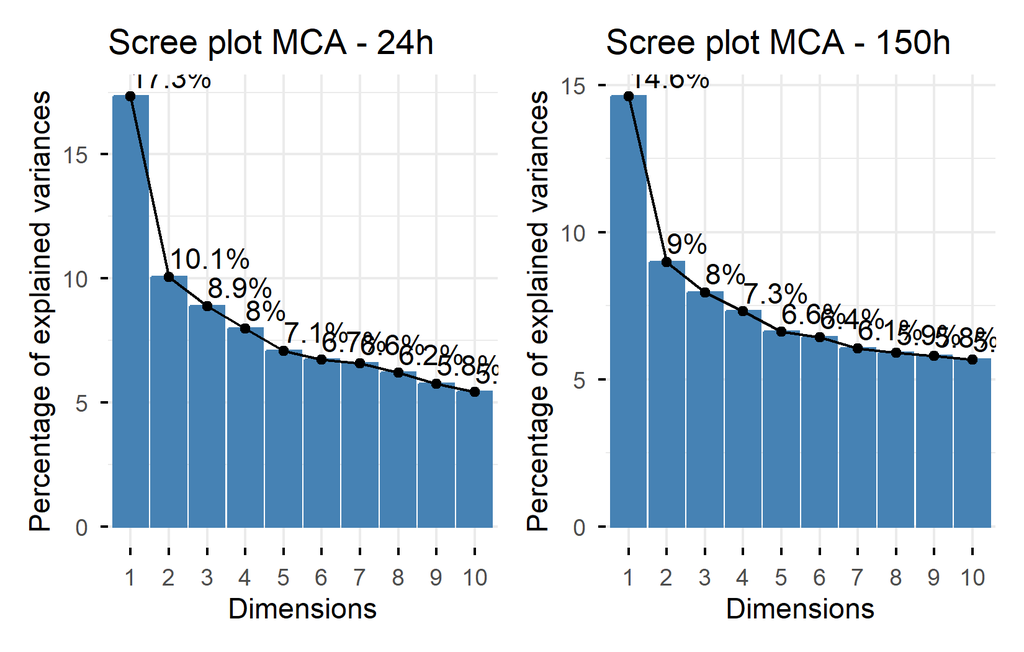

```r
# ── Scree plot ──
(fviz_screeplot(mca24$res,  addlabels = TRUE) + ggtitle("Scree plot MCA - 24h")) |
(fviz_screeplot(mca150$res, addlabels = TRUE) + ggtitle("Scree plot MCA - 150h"))
```

[figure not shown]

```r
# ── Biplot inicial: individuos + categorías superpuestos ──
fviz_mca_biplot(mca24$res,
                repel = TRUE,
                alpha.ind = 0.1,
                alpha.var = 1,
                ggtheme = theme_minimal()) +
  ggtitle("Biplot MCA - 24h") |
fviz_mca_biplot(mca150$res,
                repel = TRUE,
                alpha.ind = 0.1,
                alpha.var = 1,
                ggtheme = theme_minimal()) +
  ggtitle("Biplot MCA - 150h")
```

```r
# ── Descripción de las dimensiones ──
res.desc24  <- dimdesc(mca24$res,  axes = c(1, 2))
res.desc150 <- dimdesc(mca150$res, axes = c(1, 2))

# Dimensión 1
res.desc24[[1]]
```

```
##
## Link between the variable and the categorical variable (1-way anova)
## =============================================
##                          R2      p.value
## mutación LRRK2   0.74685807 2.947690e-70
## grupo de estudio 0.75583456 5.557438e-68
## mutación EP      0.56463263 3.113330e-43
## etnia            0.25181772 3.885406e-16
## raza             0.29081158 2.400538e-15
## Y                0.15914782 3.101869e-10
## sexo             0.12269487 4.522152e-08
## mutación APOE_E4 0.03283882 5.741468e-03
##
## Link between variable and the categories of the categorical variables
## ================================================================
##                                                 Estimate      p.value
## mutación LRRK2=mutación LRRK2_Sí               0.5043385 2.947690e-70
## mutación EP=mutación EP_Sí                     0.4306046 3.113330e-43
## grupo de estudio=Cohorte genética EP           0.7089624 3.180668e-21
## raza=Multirracial                              0.8548551 2.274370e-16
## grupo de estudio=Cohorte genética no afectada  0.5048578 2.658875e-16
## etnia=Hispano o latino                         0.3271463 3.885406e-16
## Y=Negativo                                     0.2267003 3.101869e-10
## sexo=Mujer                                     0.1962972 4.522152e-08
## mutación APOE_E4=mutación APOE_E4_Sí           0.1118973 5.741468e-03
## mutación APOE_E4=mutación APOE_E4_No          -0.1118973 5.741468e-03
## grupo de estudio=Control sano                 -0.4322632 1.193003e-03
## sexo=Hombre                                   -0.1962972 4.522152e-08
## grupo de estudio=Prodrómico                   -0.4060028 2.428995e-09
## Y=Positivo                                    -0.2267003 3.101869e-10
## raza=Blanca                                   -0.1001773 6.467392e-11
## grupo de estudio=EP                           -0.3755542 1.889503e-12
## etnia=No hispano o latino                     -0.3271463 3.885406e-16
## mutación EP=mutación EP_No                    -0.4306046 3.113330e-43
## mutación LRRK2=mutación LRRK2_No              -0.5043385 2.947690e-70
```

```r
res.desc150[[1]]
```

```
##
## Link between the variable and the categorical variable (1-way anova)
## =============================================
##                          R2       p.value
## grupo de estudio 0.81671904 8.373122e-295
## mutación EP      0.74213940 5.154746e-240
## mutación LRRK2   0.53585427 8.155972e-137
## mutación GBA     0.13602013  1.680428e-27
## etnia            0.08051048  1.954912e-15
## sexo             0.06900052  3.001177e-14
## mutación APOE_E4 0.05139329  6.700072e-11
## Y                0.02878741  1.193893e-06
## mutación SNCA    0.02114561  3.262824e-05
## raza             0.03231075  7.278489e-05
##
## Link between variable and the categories of the categorical variables
## ================================================================
##                                                  Estimate       p.value
## mutación EP=mutación EP_Sí                     0.45299242 5.154746e-240
## mutación LRRK2=mutación LRRK2_Sí               0.49136032 8.155972e-137
## grupo de estudio=Cohorte genética EP           0.64625647  7.946512e-74
## grupo de estudio=Cohorte genética no afectada  0.56907614  1.427659e-72
## mutación GBA=mutación GBA_Sí                   0.27183442  1.680428e-27
## etnia=etnia_Hispano o latino                   0.01959602  1.613298e-15
## sexo=Mujer                                     0.14157072  3.001177e-14
## mutación APOE_E4=mutación APOE_E4_Sí           0.13931680  6.700072e-11
## Y=Negativo                                     0.09059936  1.193893e-06
## mutación SNCA=mutación SNCA_Sí                 0.30402860  3.262824e-05
## raza=raza_Otra                                 0.44522954  1.825337e-02
## grupo de estudio=Prodrómico                   -0.32609027  2.379239e-03
## raza=raza_Negra o afroamericana               -0.50637339  5.119479e-05
## mutación SNCA=mutación SNCA_No                -0.30402860  3.262824e-05
## Y=Positivo                                    -0.09059936  1.193893e-06
## mutación APOE_E4=mutación APOE_E4_No          -0.13931680  6.700072e-11
## sexo=Hombre                                   -0.14157072  3.001177e-14
## etnia=etnia_No hispano o latino               -0.53352573  2.950757e-16
## grupo de estudio=Control sano                 -0.47578502  2.687398e-24
## mutación GBA=mutación GBA_No                  -0.27183442  1.680428e-27
## grupo de estudio=EP                           -0.41345733  1.185764e-53
## mutación LRRK2=mutación LRRK2_No              -0.49136032 8.155972e-137
## mutación EP=mutación EP_No                    -0.45299242 5.154746e-240
```

```r
# Dimensión 2
res.desc24[[2]]
```

```
##
## Link between the variable and the categorical variable (1-way anova)
## =============================================
##                          R2      p.value
## mutación GBA     0.40243458 2.053934e-27
## etnia            0.35896452 6.740995e-24
## grupo de estudio 0.30960252 2.367728e-17
## mutación EP      0.18600333 7.001729e-12
## raza             0.21980465 7.352379e-11
## mutación APOE_E4 0.10697255 3.685045e-07
## sexo             0.02020649 3.079243e-02
##
## Link between variable and the categories of the categorical variables
## ================================================================
##                                                  Estimate      p.value
## mutación GBA=mutación GBA_No                   0.37864140 2.053934e-27
## etnia=Hispano o latino                         0.29746858 6.740995e-24
## grupo de estudio=Prodrómico                    0.41363575 3.924713e-16
## mutación EP=mutación EP_No                     0.18822292 7.001729e-12
## raza=Multirracial                              0.22047451 3.326171e-09
## mutación APOE_E4=mutación APOE_E4_No           0.15380784 3.685045e-07
## raza=Negra o afroamericana                     0.90537298 5.184792e-03
## sexo=Hombre                                    0.06066844 3.079243e-02
## sexo=Mujer                                    -0.06066844 3.079243e-02
## raza=Asiática                                 -0.88275057 1.150338e-02
## grupo de estudio=Control sano                 -0.26534259 3.729850e-03
## grupo de estudio=Cohorte genética no afectada -0.12977844 3.607649e-03
## grupo de estudio=EP                           -0.13786764 9.729424e-05
## mutación APOE_E4=mutación APOE_E4_Sí          -0.15380784 3.685045e-07
## raza=Blanca                                   -0.32962591 3.140399e-08
## mutación EP=mutación EP_Sí                    -0.18822292 7.001729e-12
## etnia=No hispano o latino                     -0.29746858 6.740995e-24
## mutación GBA=mutación GBA_Sí                  -0.37864140 2.053934e-27
```

```r
res.desc150[[2]]
```

```
##
## Link between the variable and the categorical variable (1-way anova)
## =============================================
##                          R2      p.value
## etnia            0.37325173 1.339931e-82
## mutación GBA     0.35674357 1.811974e-79
## grupo de estudio 0.34987728 7.627467e-74
## mutación LRRK2   0.16849602 2.866739e-34
## mutación APOE_E4 0.11089746 1.986046e-22
## mutación EP      0.07603723 1.335693e-15
## raza             0.07616874 1.972832e-12
## Y                0.01634488 2.643389e-04
## sexo             0.01168692 2.062827e-03
##
## Link between variable and the categories of the categorical variables
## ================================================================
##                                                  Estimate      p.value
## mutación GBA=mutación GBA_No                   0.34513046 1.811974e-79
## etnia=etnia_Hispano o latino                   1.27063137 2.612055e-76
## etnia=etnia_No hispano o latino                0.34921000 5.120417e-68
## mutación LRRK2=mutación LRRK2_Sí               0.21601004 2.866739e-34
## grupo de estudio=Cohorte genética EP           0.30412753 8.848778e-33
## grupo de estudio=Prodrómico                    0.42781883 6.774674e-23
## mutación APOE_E4=mutación APOE_E4_No           0.16044029 1.986046e-22
## mutación EP=mutación EP_No                     0.11367467 1.335693e-15
## raza=raza_Otra                                 0.63153984 5.311740e-10
## Y=Positivo                                     0.05352011 2.643389e-04
## raza=raza_Desconocida                          0.33166531 1.359258e-03
## sexo=Hombre                                    0.04567722 2.062827e-03
## raza=raza_Multirracial                         0.04458866 2.974191e-02
## raza=raza_Asiática                            -0.61642577 3.492144e-03
## sexo=Mujer                                    -0.04567722 2.062827e-03
## Y=Negativo                                    -0.05352011 2.643389e-04
## raza=raza_Blanca                              -0.17916261 1.305282e-04
## etnia=etnia_Desconocida                       -1.61984136 6.600123e-07
## grupo de estudio=EP                           -0.18906677 6.035314e-07
## mutación EP=mutación EP_Sí                    -0.11367467 1.335693e-15
## grupo de estudio=Cohorte genética no afectada -0.40486987 5.447898e-21
## mutación APOE_E4=mutación APOE_E4_Sí          -0.16044029 1.986046e-22
## mutación LRRK2=mutación LRRK2_No              -0.21601004 2.866739e-34
## mutación GBA=mutación GBA_Sí                  -0.34513046 1.811974e-79
```

```r
# ── Variables: coordenadas, cos2 y contribuciones ──
variables24  <- get_mca_var(mca24$res)
variables150 <- get_mca_var(mca150$res)

head(variables24$coord)
```

```
##                                   Dim 1      Dim 2       Dim 3      Dim 4
## Cohorte genética EP           1.3030812  0.2351040 -0.02625183  0.9313463
## Cohorte genética no afectada  0.9355466 -0.3539531 -0.31470409 -1.0245059
## Control sano                 -0.7519429 -0.6744869 -0.43561576  1.2539707
## EP                           -0.6498262 -0.3730795 -0.31395774  0.2150286
## Prodrómico                   -0.7046554  0.9309191  0.91654449 -0.3500019
## Hombre                       -0.3060396  0.1241966  0.23994271 -0.2501908
##                                    Dim 5
## Cohorte genética EP           0.90778972
## Cohorte genética no afectada -0.40389508
## Control sano                 -0.09291116
## EP                           -0.38069620
## Prodrómico                    0.32278148
## Hombre                       -0.11252264
```

```r
head(variables24$cos2)
```

```
##                                  Dim 1      Dim 2        Dim 3      Dim 4
## Cohorte genética EP          0.3238493 0.01054192 0.0001314375 0.16543311
## Cohorte genética no afectada 0.2542618 0.03639500 0.0287710083 0.30491531
## Control sano                 0.0449164 0.03613950 0.0150744793 0.12491366
## EP                           0.1951013 0.06430853 0.0455415868 0.02136280
## Prodrómico                   0.1442461 0.25175275 0.2440379740 0.03558697
## Hombre                       0.1226949 0.02020649 0.0754199789 0.08199999
##                                     Dim 5
## Cohorte genética EP          0.1571703105
## Cohorte genética no afectada 0.0473900789
## Control sano                 0.0006857581
## EP                           0.0669611426
## Prodrómico                   0.0302668708
## Hombre                       0.0165863611
```

```r
head(variables24$contrib)
```

```
##                                 Dim 1      Dim 2       Dim 3     Dim 4
## Cohorte genética EP          9.798984  0.5499523  0.00776941 10.891301
## Cohorte genética no afectada 7.098565  1.7518549  1.56918865 18.521999
## Control sano                 1.499184  2.0796936  0.98293124  9.071504
## EP                           4.807881  2.7323047  2.19246308  1.145436
## Prodrómico                   4.027109 12.1179929 13.30998256  2.161721
## Hombre                       1.913651  0.5433683  2.29801813  2.782719
##                                    Dim 5
## Cohorte genética EP          11.64694621
## Cohorte genética no afectada  3.24026322
## Control sano                  0.05605631
## EP                            4.04128772
## Prodrómico                    2.06947595
## Hombre                        0.63356466
```

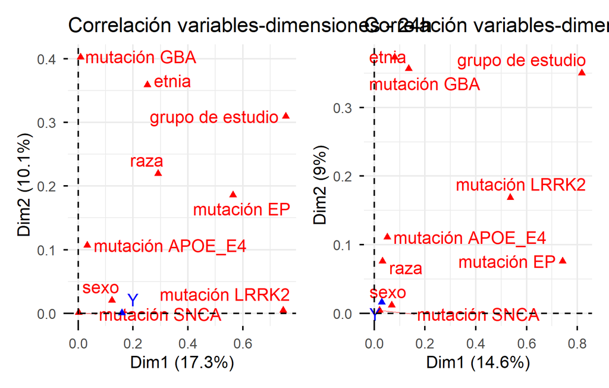

```r
# ── Correlaciones entre variables y dimensiones ──
fviz_mca_var(mca24$res,
             choice = "mca.cor",
             repel = TRUE,
             ggtheme = theme_minimal()) +
  ggtitle("Correlación variables-dimensiones - 24h") |
fviz_mca_var(mca150$res,
             choice = "mca.cor",
             repel = TRUE,
             ggtheme = theme_minimal()) +
  ggtitle("Correlación variables-dimensiones - 150h")
```

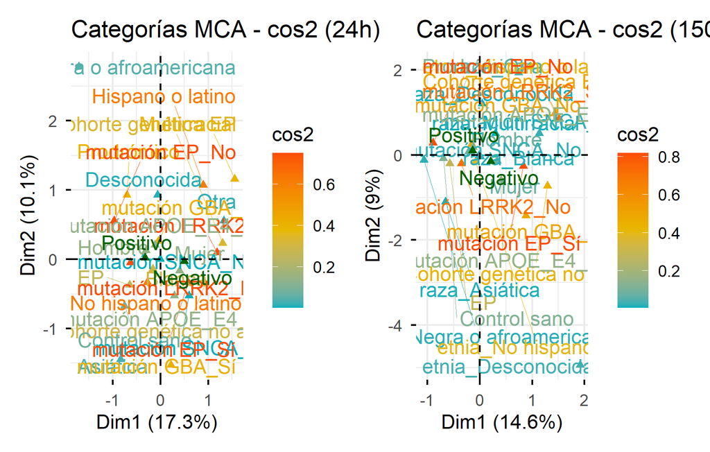

```r
# ── Categorías coloreadas por cos2 ──
fviz_mca_var(mca24$res,
             col.var = "cos2",
             gradient.cols = c("#00AFBB", "#E7B800", "#FC4E07"),
             repel = TRUE,
             ggtheme = theme_minimal()) +
  ggtitle("Categorías MCA - cos2 (24h)") |
fviz_mca_var(mca150$res,
             col.var = "cos2",
             gradient.cols = c("#00AFBB", "#E7B800", "#FC4E07"),
             repel = TRUE,
             ggtheme = theme_minimal()) +
  ggtitle("Categorías MCA - cos2 (150h)")
```

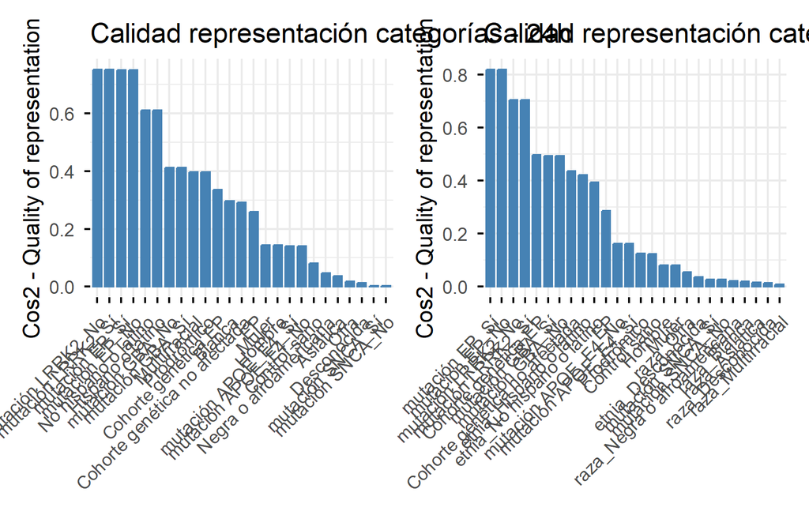

```r
# ── Calidad de representación de categorías (barplot cos2) ──
fviz_cos2(mca24$res,  choice = "var", axes = 1:2) +
  ggtitle("Calidad representación categorías - 24h") |
fviz_cos2(mca150$res, choice = "var", axes = 1:2) +
  ggtitle("Calidad representación categorías - 150h")
```

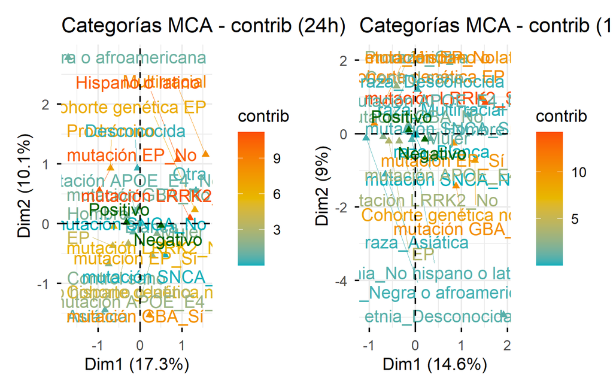

```r
# ── Categorías coloreadas por contribución ──
fviz_mca_var(mca24$res,
             col.var = "contrib",
             gradient.cols = c("#00AFBB", "#E7B800", "#FC4E07"),
             repel = TRUE,
             ggtheme = theme_minimal()) +
  ggtitle("Categorías MCA - contrib (24h)") |
fviz_mca_var(mca150$res,
             col.var = "contrib",
             gradient.cols = c("#00AFBB", "#E7B800", "#FC4E07"),
             repel = TRUE,
             ggtheme = theme_minimal()) +
  ggtitle("Categorías MCA - contrib (150h)")
```

```r
# ── Contribución de categorías a cada dimensión ──
```

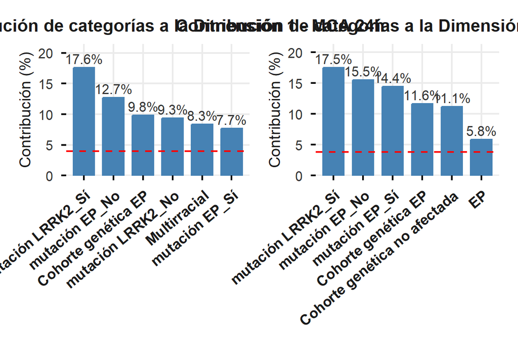

```r
plot_contrib_es(
  mca24$res,
  axes = 1,
  top = 6,
  titulo = "Contribución de categorías a la Dimensión 1 - MCA 24h"
) |
plot_contrib_es(
  mca150$res,
  axes = 1,
  top = 6,
  titulo = "Contribución de categorías a la Dimensión 1 - MCA 150h"
)
```

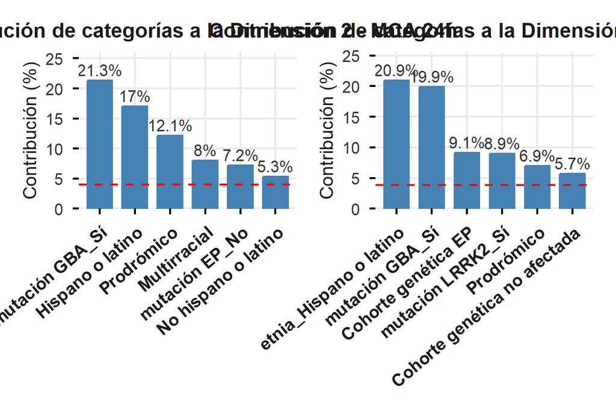

```r
plot_contrib_es(
  mca24$res,
  axes = 2,
  top = 6,
  titulo = "Contribución de categorías a la Dimensión 2 - MCA 24h"
) |
plot_contrib_es(
  mca150$res,
  axes = 2,
  top = 6,
  titulo = "Contribución de categorías a la Dimensión 2 - MCA 150h"
)
```

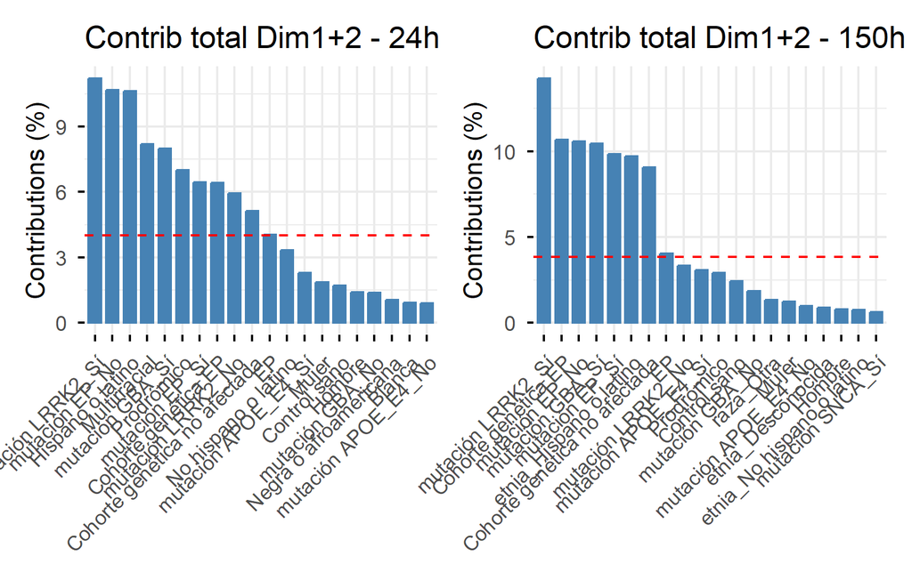

```r
fviz_contrib(mca24$res,  choice = "var", axes = 1:2, top = 20) +
  ggtitle("Contrib total Dim1+2 - 24h") |
fviz_contrib(mca150$res, choice = "var", axes = 1:2, top = 20) +
  ggtitle("Contrib total Dim1+2 - 150h")
```

```r
# ── Individuos: coordenadas, cos2 y contribuciones ──
indiv24  <- get_mca_ind(mca24$res)
indiv150 <- get_mca_ind(mca150$res)

head(indiv24$coord,  3)
```

```
##        Dim 1       Dim 2      Dim 3      Dim 4     Dim 5
## 1 -0.1086591 -0.09141433 0.53232491  0.2115501 0.1114291
## 2 -0.1086591 -0.09141433 0.53232491  0.2115501 0.1114291
## 3 -0.6410182  0.40888068 0.07001908 -0.1903158 0.1184636
```

```r
head(indiv24$cos2,   3)
```

```
##       Dim 1       Dim 2       Dim 3      Dim 4      Dim 5
## 1 0.0116969 0.008278797 0.280732226 0.04433689 0.01230087
## 2 0.0116969 0.008278797 0.280732226 0.04433689 0.01230087
## 3 0.4979557 0.202601725 0.005941318 0.04389346 0.01700669
```

```r
head(indiv24$contrib,3)
```

```
##        Dim 1      Dim 2      Dim 3     Dim 4      Dim 5
## 1 0.01657338 0.02022435 0.77707536 0.1366862 0.04268542
## 2 0.01657338 0.02022435 0.77707536 0.1366862 0.04268542
## 3 0.57679257 0.40461234 0.01344443 0.1106237 0.04824500
```

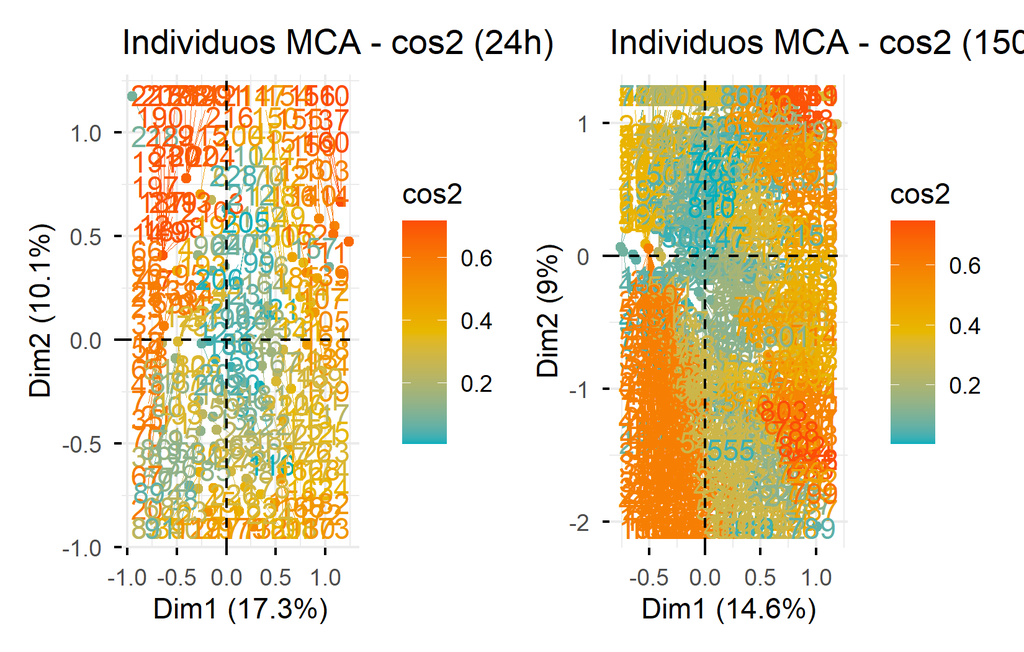

```r
# ── Individuos coloreados por cos2 ──
fviz_mca_ind(mca24$res,
             col.ind = "cos2",
             gradient.cols = c("#00AFBB", "#E7B800", "#FC4E07"),
             repel = TRUE,
             ggtheme = theme_minimal()) +
  ggtitle("Individuos MCA - cos2 (24h)") |
fviz_mca_ind(mca150$res,
             col.ind = "cos2",
             gradient.cols = c("#00AFBB", "#E7B800", "#FC4E07"),
             repel = TRUE,
             ggtheme = theme_minimal()) +
  ggtitle("Individuos MCA - cos2 (150h)")
```

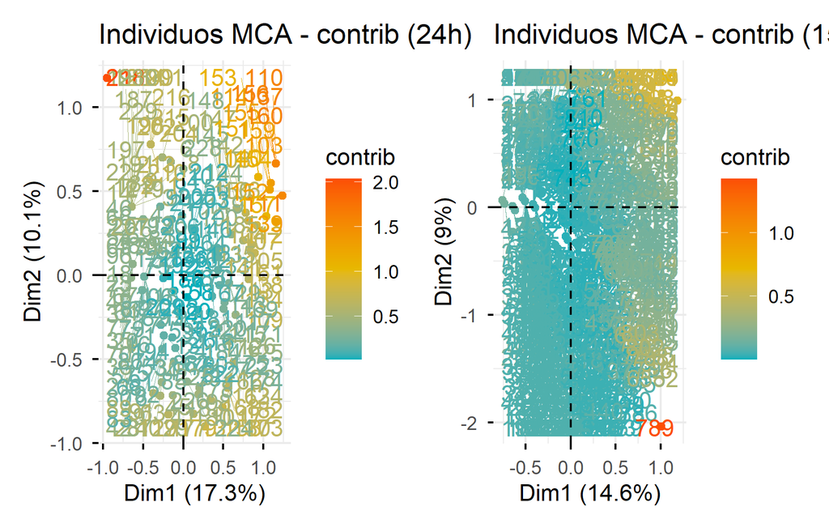

```r
# ── Individuos coloreados por contribución ──
fviz_mca_ind(mca24$res,
             col.ind = "contrib",
             gradient.cols = c("#00AFBB", "#E7B800", "#FC4E07"),
             repel = TRUE,
             ggtheme = theme_minimal()) +
  ggtitle("Individuos MCA - contrib (24h)") |
fviz_mca_ind(mca150$res,
             col.ind = "contrib",
             gradient.cols = c("#00AFBB", "#E7B800", "#FC4E07"),
             repel = TRUE,
             ggtheme = theme_minimal()) +
  ggtitle("Individuos MCA - contrib (150h)")
```

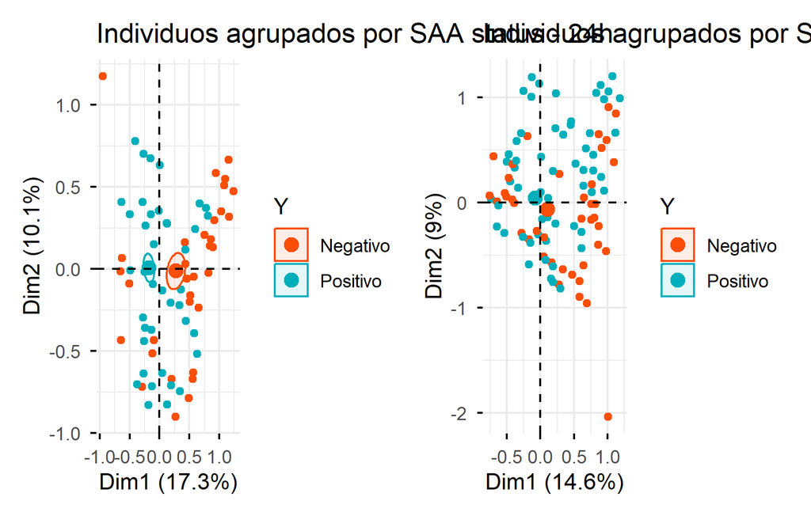

```r
# ── Agrupamiento por SAA status (Y) ──
fviz_mca_ind(mca24$res,
             label = "none",
             habillage = "Y",
             palette = c("#FC4E07", "#00AFBB"),
             addEllipses = TRUE,
             ellipse.type = "confidence",
             ggtheme = theme_minimal()) +
  ggtitle("Individuos agrupados por SAA status - 24h") |
fviz_mca_ind(mca150$res,
             label = "none",
             habillage = "Y",
             palette = c("#FC4E07", "#00AFBB"),
             addEllipses = TRUE,
             ellipse.type = "confidence",
             ggtheme = theme_minimal()) +
  ggtitle("Individuos agrupados por SAA status - 150h")
```

[figure not shown]

```r
# Individuos agrupados por grupo de estudio
fviz_mca_ind(mca24$res,
             label = "none",
             habillage = "grupo de estudio",
             addEllipses = TRUE,
             ellipse.type = "confidence",
             alpha.ind = 0.5,
             ggtheme = theme_minimal()) +
  ggtitle("MCA - grupo de estudio 24h") |
fviz_mca_ind(mca150$res,
             label = "none",
             habillage = "grupo de estudio",
             addEllipses = TRUE,
             ellipse.type = "confidence",
             alpha.ind = 0.5,
             ggtheme = theme_minimal()) +
  ggtitle("MCA - grupo de estudio 150h")
```

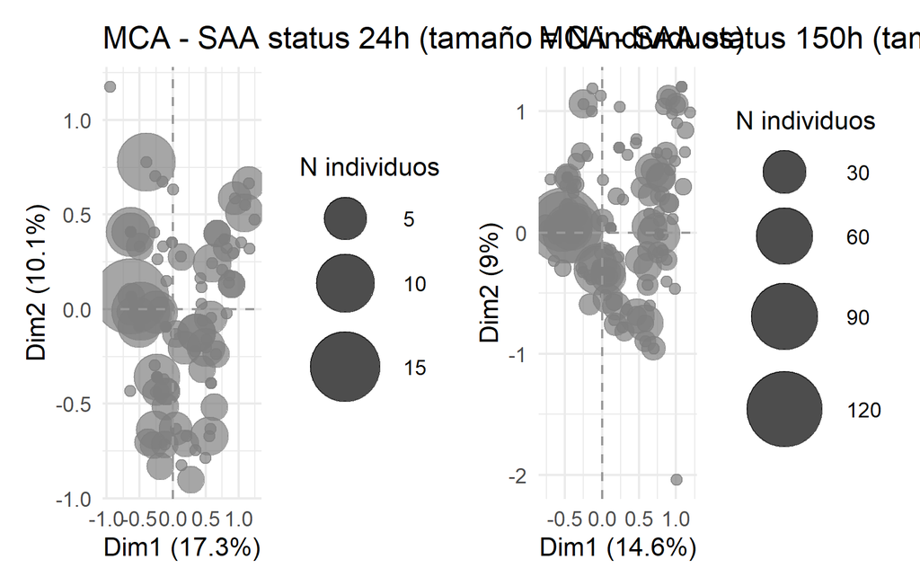

```r
# Individuos agrupados por SAA status
coords24_df <- as.data.frame(mca24$res$ind$coord[, 1:2])
colnames(coords24_df) <- c("Dim1", "Dim2")
coords24_df$SAA <- mca24$data$Y

bubble24 <- coords24_df %>%
  group_by(Dim1, Dim2, SAA) %>%
  summarise(n = n(), .groups = "drop")

p_bubble24 <- ggplot(bubble24, aes(x = Dim1, y = Dim2, size = n, color = SAA)) +
  geom_point(alpha = 0.7) +
  scale_color_manual(values = c("Negative" = "#FC4E07", "Positive" = "#00AFBB")) +
  scale_size_continuous(range = c(2, 15), name = "N individuos") +
  labs(title = "MCA - SAA status 24h (tamaño = N individuos)",
       x = paste0("Dim1 (", round(get_eigenvalue(mca24$res)[1, 2], 1), "%)"),
       y = paste0("Dim2 (", round(get_eigenvalue(mca24$res)[2, 2], 1), "%)")) +
  geom_hline(yintercept = 0, linetype = "dashed", color = "gray60") +
  geom_vline(xintercept = 0, linetype = "dashed", color = "gray60") +
  theme_minimal()

coords150_df <- as.data.frame(mca150$res$ind$coord[, 1:2])
colnames(coords150_df) <- c("Dim1", "Dim2")
coords150_df$SAA <- mca150$data$Y

bubble150 <- coords150_df %>%
  group_by(Dim1, Dim2, SAA) %>%
  summarise(n = n(), .groups = "drop")

p_bubble150 <- ggplot(bubble150, aes(x = Dim1, y = Dim2, size = n, color = SAA)) +
  geom_point(alpha = 0.7) +
  scale_color_manual(values = c("Negative" = "#FC4E07", "Positive" = "#00AFBB")) +
  scale_size_continuous(range = c(2, 15), name = "N individuos") +
  labs(title = "MCA - SAA status 150h (tamaño = N individuos)",
       x = paste0("Dim1 (", round(get_eigenvalue(mca150$res)[1, 2], 1), "%)"),
       y = paste0("Dim2 (", round(get_eigenvalue(mca150$res)[2, 2], 1), "%)")) +
  geom_hline(yintercept = 0, linetype = "dashed", color = "gray60") +
  geom_vline(xintercept = 0, linetype = "dashed", color = "gray60") +
  theme_minimal()

p_bubble24 | p_bubble150
```

# Material suplementario — Control positivo de los análisis

Repetimos los análisis FAMD filtrando únicamente los grupos **EP** y **Control sano**. Al reducir la muestra a dos grupos extremos (casi todos SAA+ en EP, casi todos SAA− en controles), esperamos que `grupo de estudio` explique una proporción mucho mayor de la varianza total, confirmando que el biomarcador SAA está alineado con el diagnóstico clínico.

```r
## Material suplementario: control positivo (solo EP vs Control sano)

df_24_cp <- df_24 %>%
  filter(
    (`grupo de estudio` == "EP" & `mutación EP` == "No") |
    (`grupo de estudio` == "Control sano")
  ) %>%
  select(-`mutación GBA`,
         -`mutación LRRK2`,
         -`mutación SNCA`,
         -`mutación APOE_E4`,
         -`mutación EP`,
         -etnia) %>%
  droplevels()

df_150_cp <- df_150 %>%
  filter(
    (`grupo de estudio` == "EP" & `mutación EP` == "No") |
    (`grupo de estudio` == "Control sano")
  ) %>%
  select(-`mutación GBA`,
         -`mutación LRRK2`,
         -`mutación SNCA`,
         -`mutación APOE_E4`,
         -`mutación EP`,
         -etnia) %>%
  droplevels()


# Convertir a factor
df_24_cp <- df_24_cp %>%
  mutate(across(where(is.character), as.factor))
df_150_cp <- df_150_cp %>%
  mutate(across(where(is.character), as.factor))

# Eliminar columnas con un solo valor único
df_24_cp <- df_24_cp[, sapply(df_24_cp, function(x) n_distinct(x, na.rm = TRUE) > 1)]
df_150_cp <- df_150_cp[, sapply(df_150_cp, function(x) n_distinct(x, na.rm = TRUE) > 1)]

# Imputación
df_24_cp_imp  <- imputar_famd_con_HC_cero(df_24_cp,  ncp = 2)
df_150_cp_imp <- imputar_famd_con_HC_cero(df_150_cp, ncp = 2)

# Calcular índices AQUÍ, después de todas las transformaciones
y_index_24_cp  <- which(names(df_24_cp_imp) == "Y")
y_index_150_cp <- which(names(df_150_cp_imp) == "Y")

res.famd24_cp <- FAMD(
  df_24_cp_imp,
  ncp = 10,
  sup.var = which(names(df_24_cp_imp) == "Y"),
  graph = FALSE
)

res.famd150_cp <- FAMD(
  df_150_cp_imp,
  ncp = 10,
  sup.var = which(names(df_150_cp_imp) == "Y"),
  graph = FALSE
)
```

#Análisis de regresión penalizada

```r
# Regresión de Firth - control positivo 24h
modelo_firth24_cp <- logistf(Y ~ ., data = df_24_cp_imp)
summary(modelo_firth24_cp)
```

```
## logistf(formula = Y ~ ., data = df_24_cp_imp)
##
## Model fitted by Penalized ML
## Coefficients:
##                               coef   se(coef)  lower 0.95 upper 0.95
## (Intercept)            -2.66159318 3.84080530 -10.7379106  6.0962380
## `grupo de edad`50-59   -0.68634689 0.97908577  -2.8299133  1.4081975
## `grupo de edad`60-69    0.07431148 1.05793662  -2.3764954  2.4243424
## `grupo de edad`70-79   -0.23748517 1.12645930  -2.7341125  2.2564705
## `grupo de edad`≥80     -1.55059965 1.45521884  -4.8671109  1.3787794
## sexoMujer              -0.62903810 0.63365132  -2.0039415  0.6962642
## razaBlanca             -0.02013215 1.90448992  -3.6368708  5.2290849
## razaMultirracial       -0.17335119 2.39957300  -4.5994808  5.9871047
## `grupo de estudio`EP    2.79344426 1.48113241  -0.1318705  6.1259678
## `valor MDS UPDRS III`  -0.01137034 0.06544457  -0.1734184  0.1211684
## `Estadío Hoehn & Yahr` -0.10017721 1.00214247  -2.1704056  2.3415243
## `valor MoCA`            0.07843361 0.13083238  -0.2345024  0.3488839
##                               Chisq          p method
## (Intercept)            0.4397624239 0.50723715      2
## `grupo de edad`50-59   0.4372539968 0.50845082      2
## `grupo de edad`60-69   0.0040991462 0.94895066      2
## `grupo de edad`70-79   0.0382616930 0.84491859      2
## `grupo de edad`≥80     1.0516562482 0.30512595      2
## sexoMujer              0.8848444691 0.34687824      2
## razaBlanca             0.0001073961 0.99173150      2
## razaMultirracial       0.0049580711 0.94386449      2
## `grupo de estudio`EP   3.5000807289 0.06136584      2
## `valor MDS UPDRS III`  0.0255548628 0.87299224      2
## `Estadío Hoehn & Yahr` 0.0083504782 0.92718990      2
## `valor MoCA`           0.3131066224 0.57578007      2
##
## Method: 1-Wald, 2-Profile penalized log-likelihood, 3-None
##
## Likelihood ratio test=22.97878 on 11 df, p=0.01779732, n=57
## Wald test = 19.67114 on 11 df, p = 0.05005994
```

```r
# Regresión de Firth - control positivo 150h
modelo_firth150_cp <- logistf(Y ~ ., data = df_150_cp_imp)
summary(modelo_firth150_cp)
```

```
## logistf(formula = Y ~ ., data = df_150_cp_imp)
##
## Model fitted by Penalized ML
## Coefficients:
##                                   coef   se(coef)  lower 0.95 upper 0.95
## (Intercept)               -3.765249923 3.08736981 -9.79234936 3.37299612
## `grupo de edad`50-59       0.266406816 0.67493394 -1.23919076 1.66255823
## `grupo de edad`60-69       0.253284821 0.63877851 -1.19669717 1.55588829
## `grupo de edad`70-79       0.510262688 0.70785296 -1.04959281 1.98411996
## `grupo de edad`≥80        -0.906436130 1.08353608 -3.11446356 1.73743476
## sexoMujer                  0.113491921 0.38535108 -0.69154067 0.94878287
## razaBlanca                 0.341018597 1.50420759 -4.57798100 2.74345774
## razaDesconocida           -0.557143765 2.18385652 -6.07096579 5.89042908
## razaMultirracial           0.971556507 1.96979473 -4.50526233 5.19388926
## razaNegra o afroamericana  0.642175475 1.92273399 -4.87682611 4.48374973
## razaOtra                   0.322175388 2.07823950 -5.02897768 5.67974039
## `grupo de estudio`EP       5.454754766 0.80032059  3.88081548 7.20166352
## `valor MDS UPDRS III`     -0.027906796 0.03152693 -0.09349296 0.03902088
## `Estadío Hoehn & Yahr`     0.143842001 0.53299856 -0.97384888 1.28374875
## `valor MoCA`               0.007675182 0.09150404 -0.19950033 0.18956104
##                                  Chisq            p method
## (Intercept)                1.196429989 2.740364e-01      2
## `grupo de edad`50-59       0.127948660 7.205685e-01      2
## `grupo de edad`60-69       0.127125095 7.214317e-01      2
## `grupo de edad`70-79       0.427149759 5.133908e-01      2
## `grupo de edad`≥80         0.556750241 4.555726e-01      2
## sexoMujer                  0.075260761 7.838257e-01      2
## razaBlanca                 0.045511924 8.310655e-01      2
## razaDesconocida            0.048458115 8.257683e-01      2
## razaMultirracial           0.171052576 6.791780e-01      2
## razaNegra o afroamericana  0.073201504 7.867312e-01      2
## razaOtra                   0.022743335 8.801264e-01      2
## `grupo de estudio`EP      51.441485161 7.376322e-13      2
## `valor MDS UPDRS III`      0.684283195 4.081157e-01      2
## `Estadío Hoehn & Yahr`     0.063787957 8.006061e-01      2
## `valor MoCA`               0.006036485 9.380708e-01      2
##
## Method: 1-Wald, 2-Profile penalized log-likelihood, 3-None
##
## Likelihood ratio test=336.8167 on 14 df, p=0, n=400
## Wald test = 173.3816 on 14 df, p = 0
```

```
## `height` was translated to `width`.
```

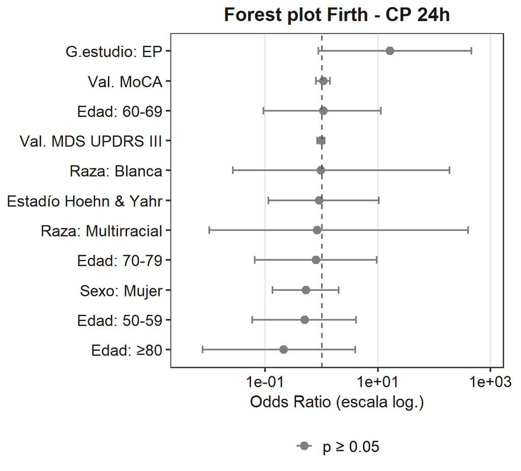

```r
# Forest plot CP
forest_firth(modelo_firth24_cp,  "Forest plot Firth - CP 24h")
```

```
## `height` was translated to `width`.
```

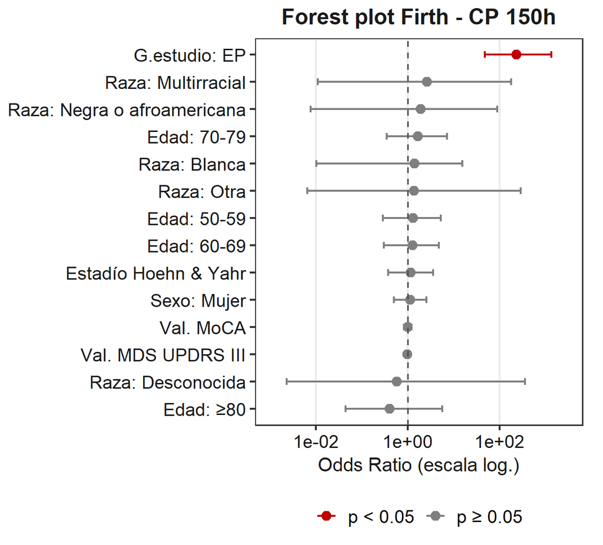

```r
forest_firth(modelo_firth150_cp, "Forest plot Firth - CP 150h")
```

#Matriz de correlacion - control positivo

[figure not shown]

```r
# Matriz de correlación - control positivo 24h
df_24_cp_num <- df_24_cp_imp %>%
  select(-Y) %>%
  mutate(across(where(is.factor), as.numeric))

cor_24_cp <- cor(df_24_cp_num, method = "spearman", use = "pairwise.complete.obs")

corrplot(cor_24_cp, method = "color", type = "upper",
         tl.cex = 2.0, cl.cex = 1.8, tl.col = "black",
         title = "Matriz de correlaciones — CP 24h",
         cex.main = 2.5,
         mar = c(0, 0, 4, 0))
```

[figure not shown]

```r
# Matriz de correlación - control positivo 150h
df_150_cp_num <- df_150_cp_imp %>%
  select(-Y) %>%
  mutate(across(where(is.factor), as.numeric))

cor_150_cp <- cor(df_150_cp_num, method = "spearman", use = "pairwise.complete.obs")

corrplot(cor_150_cp, method = "color", type = "upper",
         tl.cex = 2.0, cl.cex = 1.8, tl.col = "black",
         title = "Matriz de correlaciones — CP 150h",
         cex.main = 2.5,
         mar = c(0, 0, 4, 0))
```

## Screeplots control positivo

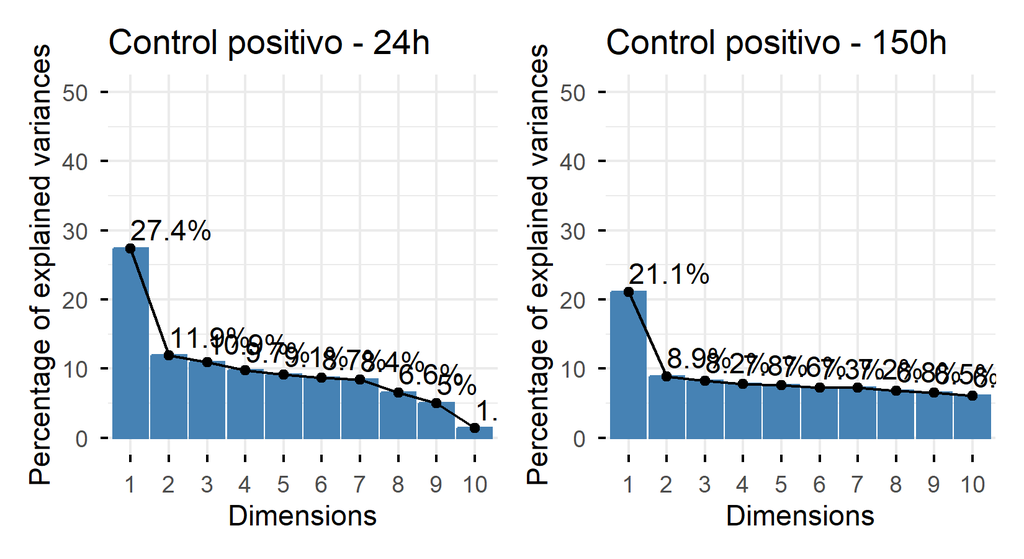

```r
eig.val24_cp <- get_eigenvalue(res.famd24_cp)
eig.val150_cp <- get_eigenvalue(res.famd150_cp)

(fviz_screeplot(res.famd24_cp, addlabels = TRUE, ylim = c(0, 50)) +
  ggtitle("Control positivo - 24h")) |
(fviz_screeplot(res.famd150_cp, addlabels = TRUE, ylim = c(0, 50)) +
  ggtitle("Control positivo - 150h"))
```

## Contribucion de las variables a la varianza en el control positivo

```r
plot_contrib <- function(res, dim, titulo) {
  contrib <- get_famd_var(res)$contrib

  df <- as.data.frame(contrib)
  df$variable <- rownames(df)

  df <- df %>%
    arrange(desc(.data[[dim]])) %>%
    slice(1:10)

  ggplot(df, aes(x = reorder(variable, - .data[[dim]]),
                 y = .data[[dim]])) +
    geom_col(fill = "#4C78A8") +
    geom_text(aes(label = paste0(round(.data[[dim]], 1), "%")),
              vjust = -0.4, size = 6) +
    labs(
      title = titulo,
      x = "Variables",
      y = "% contribución"
    ) +
    theme_minimal() +
    theme(
      text = element_text(size = 9),
      axis.text.x = element_text(size = 9, angle = 60, hjust = 1, vjust = 1)
    ) +
    ylim(0, max(df[[dim]]) * 1.2)
}
```

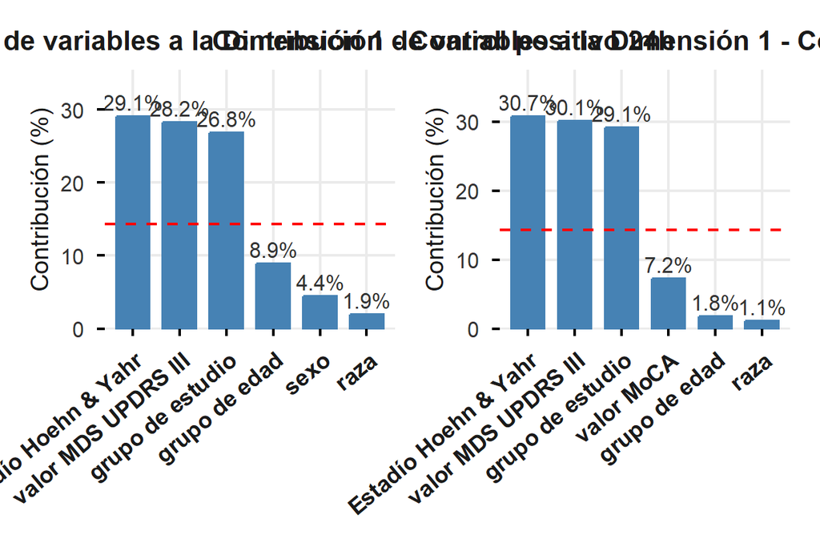

```r
plot_contrib_es(
  res.famd24_cp,
  axes = 1,
  top = 6,
  titulo = "Contribución de variables a la Dimensión 1 - Control positivo 24h"
) |
plot_contrib_es(
  res.famd150_cp,
  axes = 1,
  top = 6,
  titulo = "Contribución de variables a la Dimensión 1 - Control positivo 150h"
)
```

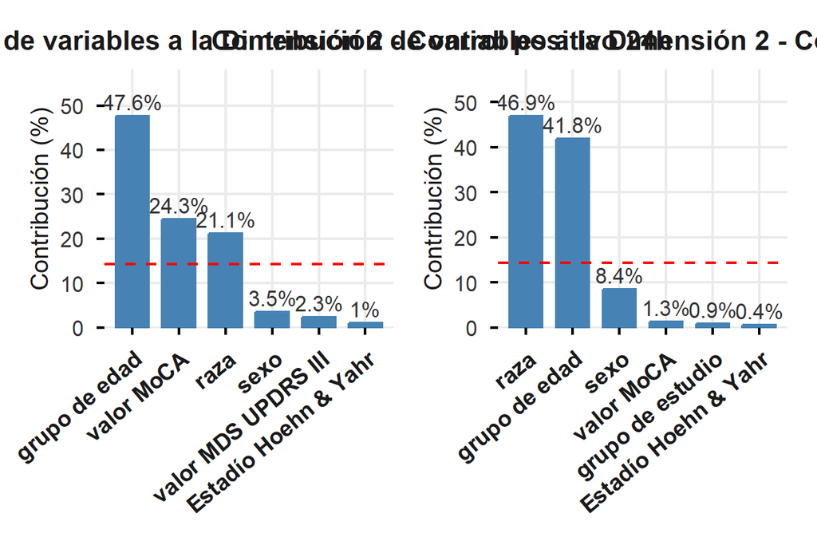

```r
plot_contrib_es(
  res.famd24_cp,
  axes = 2,
  top = 6,
  titulo = "Contribución de variables a la Dimensión 2 - Control positivo 24h"
) |
plot_contrib_es(
  res.famd150_cp,
  axes = 2,
  top = 6,
  titulo = "Contribución de variables a la Dimensión 2 - Control positivo 150h"
)
```

[figure not shown]

```r
plot_quali_by_var(res.famd24_cp,  titulo = "Categorías variables cualitativas - control positivo 24h") |
plot_quali_by_var(res.famd150_cp, titulo = "Categorías variables cualitativas - control positivo 150h")
```

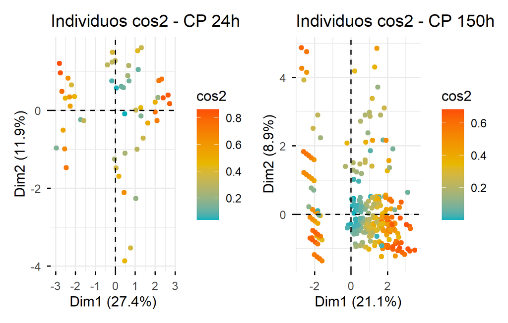

```r
# INDIVIDUOS cos2 - CONTROL POSITIVO
ind24_cp  <- get_famd_ind(res.famd24_cp)
ind150_cp <- get_famd_ind(res.famd150_cp)

p_cos2_24_cp <- fviz_famd_ind(
  res.famd24_cp,
  col.ind = "cos2",
  gradient.cols = c("#00AFBB", "#E7B800", "#FC4E07"),
  geom = "point",
  repel = TRUE
) + ggtitle("Individuos cos2 - CP 24h")
p_cos2_24_cp$layers[[1]] <- NULL

p_cos2_150_cp <- fviz_famd_ind(
  res.famd150_cp,
  col.ind = "cos2",
  gradient.cols = c("#00AFBB", "#E7B800", "#FC4E07"),
  geom = "point",
  repel = TRUE
) + ggtitle("Individuos cos2 - CP 150h")
p_cos2_150_cp$layers[[1]] <- NULL

p_cos2_24_cp | p_cos2_150_cp
```

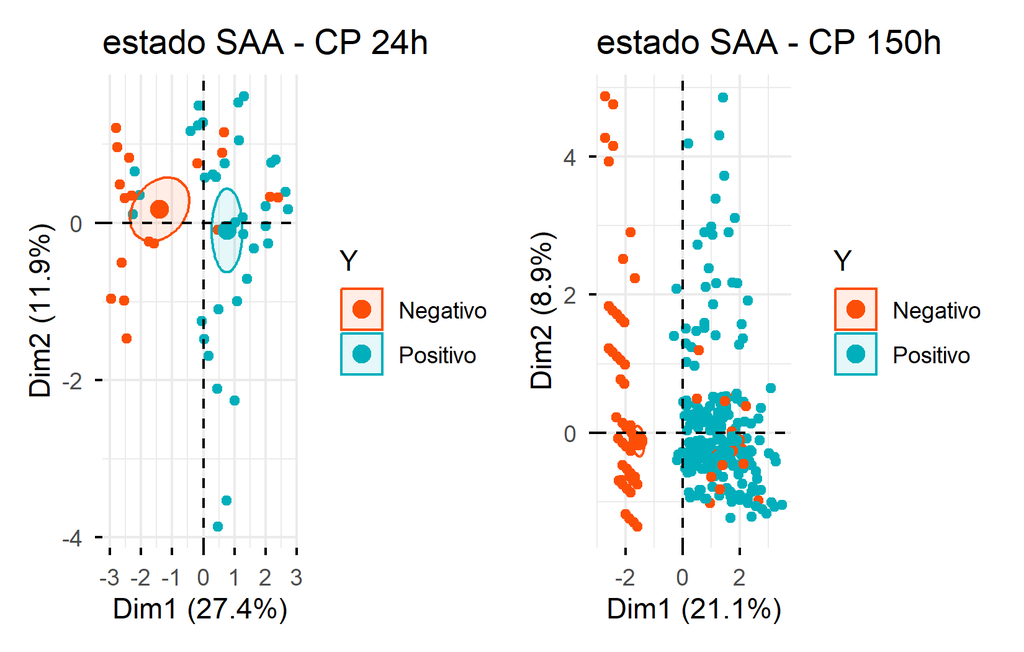

```r
# SAA STATUS - CONTROL POSITIVO
p_saa_24_cp <- fviz_famd_ind(
  res.famd24_cp,
  habillage = "Y",
  palette = c("#FC4E07", "#00AFBB"),
  addEllipses = TRUE,
  ellipse.type = "confidence",
  geom = "point",
  repel = TRUE
) + ggtitle("estado SAA - CP 24h")
p_saa_24_cp$layers[[1]] <- NULL

p_saa_150_cp <- fviz_famd_ind(
  res.famd150_cp,
  habillage = "Y",
  palette = c("#FC4E07", "#00AFBB"),
  addEllipses = TRUE,
  ellipse.type = "confidence",
  geom = "point",
  repel = TRUE
) + ggtitle("estado SAA - CP 150h")
p_saa_150_cp$layers[[1]] <- NULL

p_saa_24_cp | p_saa_150_cp
```

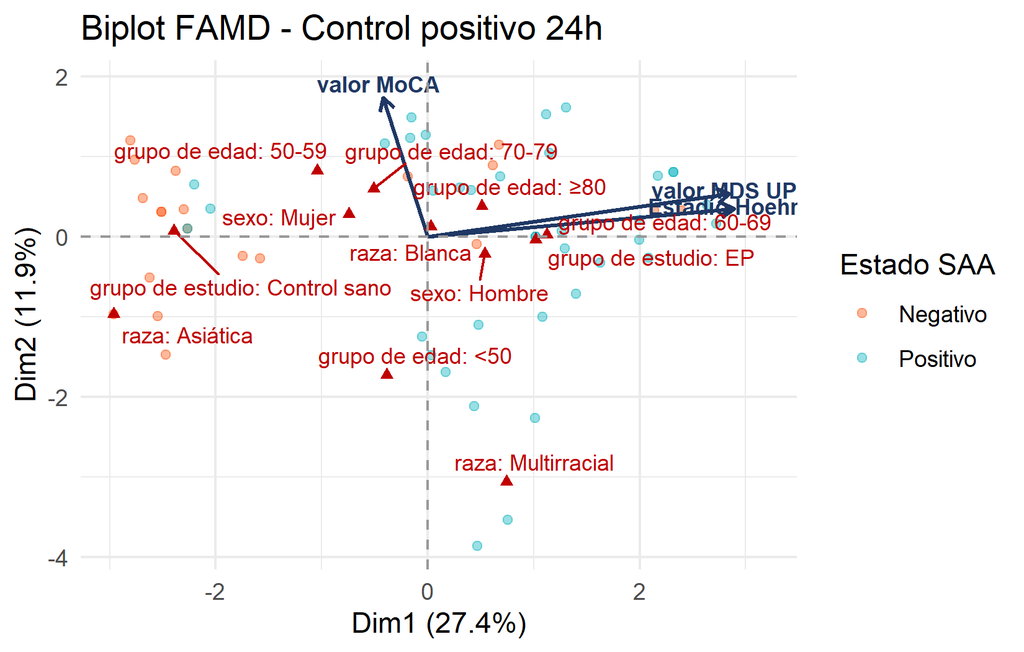

```r
# ── Coordenadas individuos CP ──
ind_coords_24_cp <- as.data.frame(get_famd_ind(res.famd24_cp)$coord[, 1:2])
colnames(ind_coords_24_cp) <- c("Dim1", "Dim2")
ind_coords_24_cp$SAA <- res.famd24_cp$call$X[["Y"]]

ind_coords_150_cp <- as.data.frame(get_famd_ind(res.famd150_cp)$coord[, 1:2])
colnames(ind_coords_150_cp) <- c("Dim1", "Dim2")
ind_coords_150_cp$SAA <- res.famd150_cp$call$X[["Y"]]

# ── Coordenadas variables cuantitativas CP ──
quanti_coords_24_cp <- as.data.frame(res.famd24_cp$quanti.var$coord[, 1:2])
colnames(quanti_coords_24_cp) <- c("Dim1", "Dim2")
quanti_coords_24_cp$variable <- rownames(quanti_coords_24_cp)
scale_factor_24_cp <- max(abs(ind_coords_24_cp[, 1:2])) * 0.8
quanti_coords_24_cp[, 1:2] <- quanti_coords_24_cp[, 1:2] * scale_factor_24_cp

quanti_coords_150_cp <- as.data.frame(res.famd150_cp$quanti.var$coord[, 1:2])
colnames(quanti_coords_150_cp) <- c("Dim1", "Dim2")
quanti_coords_150_cp$variable <- rownames(quanti_coords_150_cp)
scale_factor_150_cp <- max(abs(ind_coords_150_cp[, 1:2])) * 0.8
quanti_coords_150_cp[, 1:2] <- quanti_coords_150_cp[, 1:2] * scale_factor_150_cp

# ── Coordenadas variables cualitativas CP con etiquetas variable: categoría ──
quali_coords_24_cp <- obtener_quali_coords_famd(res.famd24_cp)

quali_coords_150_cp <- obtener_quali_coords_famd(res.famd150_cp)

eig_24_cp  <- get_eigenvalue(res.famd24_cp)
eig_150_cp <- get_eigenvalue(res.famd150_cp)

# ── Biplots CP ──
# Biplot FAMD - Control positivo 24h

# Asegurar que Y existe si estás ejecutando chunks sueltos
if (!"Y" %in% names(df_24_cp) && "estado SAA" %in% names(df_24_cp)) {
  df_24_cp$Y <- df_24_cp$`estado SAA`
  df_24_cp$`estado SAA` <- NULL
}

df_24_cp$Y <- factor(df_24_cp$Y, levels = c("Negativo", "Positivo"))

ind_coords_24_cp <- as.data.frame(get_famd_ind(res.famd24_cp)$coord[, 1:2])
colnames(ind_coords_24_cp) <- c("Dim1", "Dim2")

# Usar Y desde el objeto FAMD si está disponible; si no, desde df_24_cp
if ("Y" %in% names(res.famd24_cp$call$X)) {
  ind_coords_24_cp$SAA <- res.famd24_cp$call$X[["Y"]]
} else {
  ind_coords_24_cp$SAA <- df_24_cp$Y
}

ind_coords_24_cp$SAA <- factor(ind_coords_24_cp$SAA, levels = c("Negativo", "Positivo"))

quanti_coords_24_cp <- as.data.frame(res.famd24_cp$quanti.var$coord[, 1:2])
colnames(quanti_coords_24_cp) <- c("Dim1", "Dim2")
quanti_coords_24_cp$variable <- rownames(quanti_coords_24_cp)

scale_factor_24_cp <- max(abs(ind_coords_24_cp[, 1:2]), na.rm = TRUE) * 0.8
quanti_coords_24_cp[, 1:2] <- quanti_coords_24_cp[, 1:2] * scale_factor_24_cp

quali_coords_24_cp <- obtener_quali_coords_famd(res.famd24_cp)

eig_24_cp <- get_eigenvalue(res.famd24_cp)

ggplot() +
  geom_point(
    data = ind_coords_24_cp,
    aes(x = Dim1, y = Dim2, color = SAA),
    alpha = 0.4,
    size = 1.5
  ) +
  scale_color_manual(
    values = c("Negativo" = "#FC4E07", "Positivo" = "#00AFBB"),
    name = "Estado SAA",
    drop = FALSE
  ) +
  geom_segment(
    data = quanti_coords_24_cp,
    aes(x = 0, y = 0, xend = Dim1, yend = Dim2),
    arrow = arrow(length = unit(0.2, "cm")),
    color = "#1F3864",
    linewidth = 0.7
  ) +
  geom_text(
    data = quanti_coords_24_cp,
    aes(x = Dim1 * 1.1, y = Dim2 * 1.1, label = variable),
    color = "#1F3864",
    size = 3,
    fontface = "bold"
  ) +
  geom_point(
    data = quali_coords_24_cp,
    aes(x = Dim1, y = Dim2),
    shape = 17,
    size = 1.5,
    color = "#C00000"
  ) +
  geom_text_repel(
    data = quali_coords_24_cp,
    aes(x = Dim1, y = Dim2, label = categoria),
    color = "#C00000",
    size = 3,
    max.overlaps = 15
  ) +
  geom_hline(yintercept = 0, linetype = "dashed", color = "gray60") +
  geom_vline(xintercept = 0, linetype = "dashed", color = "gray60") +
  labs(
    title = "Biplot FAMD - Control positivo 24h",
    x = paste0("Dim1 (", round(eig_24_cp[1, 2], 1), "%)"),
    y = paste0("Dim2 (", round(eig_24_cp[2, 2], 1), "%)")
  ) +
  theme_minimal() +
  theme(legend.position = "right")
```

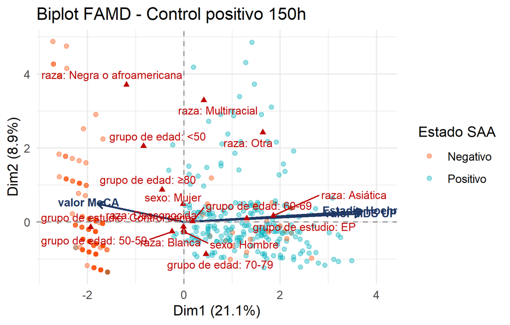

```r
# Biplot FAMD - Control positivo 150h

# Asegurar que Y existe si estás ejecutando chunks sueltos
if (!"Y" %in% names(df_150_cp) && "estado SAA" %in% names(df_150_cp)) {
  df_150_cp$Y <- df_150_cp$`estado SAA`
  df_150_cp$`estado SAA` <- NULL
}

df_150_cp$Y <- factor(df_150_cp$Y, levels = c("Negativo", "Positivo"))

ind_coords_150_cp <- as.data.frame(get_famd_ind(res.famd150_cp)$coord[, 1:2])
colnames(ind_coords_150_cp) <- c("Dim1", "Dim2")

# Usar Y desde el objeto FAMD si está disponible; si no, desde df_150_cp
if ("Y" %in% names(res.famd150_cp$call$X)) {
  ind_coords_150_cp$SAA <- res.famd150_cp$call$X[["Y"]]
} else {
  ind_coords_150_cp$SAA <- df_150_cp$Y
}

ind_coords_150_cp$SAA <- factor(ind_coords_150_cp$SAA, levels = c("Negativo", "Positivo"))

quanti_coords_150_cp <- as.data.frame(res.famd150_cp$quanti.var$coord[, 1:2])
colnames(quanti_coords_150_cp) <- c("Dim1", "Dim2")
quanti_coords_150_cp$variable <- rownames(quanti_coords_150_cp)

scale_factor_150_cp <- max(abs(ind_coords_150_cp[, 1:2]), na.rm = TRUE) * 0.8
quanti_coords_150_cp[, 1:2] <- quanti_coords_150_cp[, 1:2] * scale_factor_150_cp

quali_coords_150_cp <- obtener_quali_coords_famd(res.famd150_cp)

eig_150_cp <- get_eigenvalue(res.famd150_cp)

ggplot() +
  geom_point(
    data = ind_coords_150_cp,
    aes(x = Dim1, y = Dim2, color = SAA),
    alpha = 0.4,
    size = 1.5
  ) +
  scale_color_manual(
    values = c("Negativo" = "#FC4E07", "Positivo" = "#00AFBB"),
    name = "Estado SAA",
    drop = FALSE
  ) +
  geom_segment(
    data = quanti_coords_150_cp,
    aes(x = 0, y = 0, xend = Dim1, yend = Dim2),
    arrow = arrow(length = unit(0.2, "cm")),
    color = "#1F3864",
    linewidth = 0.7
  ) +
  geom_text(
    data = quanti_coords_150_cp,
    aes(x = Dim1 * 1.1, y = Dim2 * 1.1, label = variable),
    color = "#1F3864",
    size = 3,
    fontface = "bold"
  ) +
  geom_point(
    data = quali_coords_150_cp,
    aes(x = Dim1, y = Dim2),
    shape = 17,
    size = 1.5,
    color = "#C00000"
  ) +
  geom_text_repel(
    data = quali_coords_150_cp,
    aes(x = Dim1, y = Dim2, label = categoria),
    color = "#C00000",
    size = 3,
    max.overlaps = 15
  ) +
  geom_hline(yintercept = 0, linetype = "dashed", color = "gray60") +
  geom_vline(xintercept = 0, linetype = "dashed", color = "gray60") +
  labs(
    title = "Biplot FAMD - Control positivo 150h",
    x = paste0("Dim1 (", round(eig_150_cp[1, 2], 1), "%)"),
    y = paste0("Dim2 (", round(eig_150_cp[2, 2], 1), "%)")
  ) +
  theme_minimal() +
  theme(legend.position = "right")
```

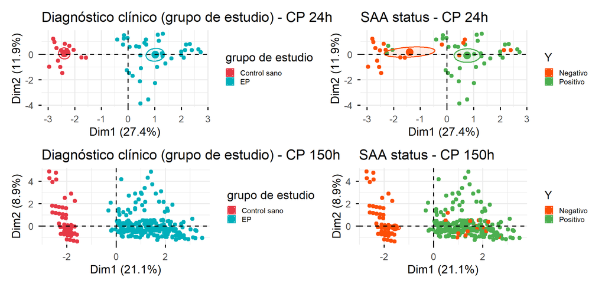

```r
# grupo de estudio 24h
p1_cp <- fviz_famd_ind(
  res.famd24_cp,
  habillage = "grupo de estudio",
  palette = c("#E63946", "#00AFBB"),
  addEllipses = TRUE, ellipse.type = "confidence",
  geom = "point", repel = FALSE) +
  ggtitle("Diagnóstico clínico (grupo de estudio) - CP 24h") +
  theme(legend.position = "right", legend.text = element_text(size = 7), legend.key.size = unit(0.3, "cm"))
p1_cp$layers[[1]] <- NULL
p1_cp <- add_group_labels(p1_cp, res.famd24_cp, "grupo de estudio")

# SAA status 24h
p3_cp <- fviz_famd_ind(
  res.famd24_cp,
  habillage = "Y",
  palette = c("#FC4E07", "#4CAF50"),
  addEllipses = TRUE, ellipse.type = "confidence",
  geom = "point", repel = FALSE) +
  ggtitle("SAA status - CP 24h") +
  theme(legend.position = "right", legend.text = element_text(size = 7), legend.key.size = unit(0.3, "cm"))
p3_cp$layers[[1]] <- NULL
p3_cp <- add_group_labels(p3_cp, res.famd24_cp, "Y")

# grupo de estudio 150h
p1_150_cp <- fviz_famd_ind(
  res.famd150_cp,
  habillage = "grupo de estudio",
  palette = c("#E63946", "#00AFBB"),
  addEllipses = TRUE, ellipse.type = "confidence",
  geom = "point", repel = FALSE) +
  ggtitle("Diagnóstico clínico (grupo de estudio) - CP 150h") +
  theme(legend.position = "right", legend.text = element_text(size = 7), legend.key.size = unit(0.3, "cm"))
p1_150_cp$layers[[1]] <- NULL
p1_150_cp <- add_group_labels(p1_150_cp, res.famd150_cp, "grupo de estudio")

# SAA status 150h
p3_150_cp <- fviz_famd_ind(
  res.famd150_cp,
  habillage = "Y",
  palette = c("#FC4E07", "#4CAF50"),
  addEllipses = TRUE, ellipse.type = "confidence",
  geom = "point", repel = FALSE) +
  ggtitle("SAA status - CP 150h") +
  theme(legend.position = "right", legend.text = element_text(size = 7), legend.key.size = unit(0.3, "cm"))
p3_150_cp$layers[[1]] <- NULL
p3_150_cp <- add_group_labels(p3_150_cp, res.famd150_cp, "Y")



# Panel final
(p1_cp | p3_cp) /
(p1_150_cp | p3_150_cp)
```